# SIG30 dGEP Analysis: waggr

EYW

2026-08-11

# Goal

Test effects of **SIG30** CRISPR knockouts on dGEPs (sparse-PCA components derived from the sibling project **SIG18**). Each SIG30 sample gets one score per SIG18 program, computed by decoupler’s `waggr` in `01_dGEP_scoring_SIG30.ipynb`.

A linear model is used to associate perturbations with dGEP changes. Scores are z-scaled per program before fitting, matching how SIG18 fits its own programs (`SIG18/analysis/spca/03_spca_annotation.Rmd`), so estimates from the two experiments are on the same scale: SDs of that program’s score.

# Import

```r
library(tidyverse)
library(patchwork)
library(broom)
library(emmeans)
```

```r
library(ggrepel)
library(RColorBrewer)
library(pheatmap)
library(gridExtra)
knitr::opts_chunk$set(echo = TRUE, warning = FALSE, message = FALSE)

source("../../functions/r_custom/plotting_fxns.R")
theme_set(theme_Publication())

# ---- config ----
score_method <- "waggr"
sig_alpha    <- 0.1   # used for "significant" labels and counts
out_dir      <- "../../analysis_outs/inference_SIG18"

# SIG18 sPCA/dGEP outputs this analysis reads (sibling repo, see CLAUDE.md)
sig18_dir             <- "/data1/rudenska/EYW/git_projects/SIG18"
sig18_lm_scored_clean <- file.path(sig18_dir, "analysis_outs/spca/lm_scored_zscore_degs_alpha10.0_sPCA_clean.csv")
sig18_lm_fit_path     <- file.path(sig18_dir, "analysis_outs/spca/lm_fit_zscore_degs_alpha10.0_sPCA.csv")
```

```r
# Pick the top `n` programs that respond to ONE ligand only: the `p_col`/`est_col`
# main effect clears the thresholds while the other ligand's main effect
# (`other_p_col`/`other_est_col`) does not. Synergistic programs are excluded so
# the three classes below stay mutually exclusive.
ligand_only_components <- function(df, p_col, est_col, other_p_col, other_est_col,
                                   p_threshold = 0.1, est_threshold = 0.5, n = 5) {
  df %>%
    filter(!grepl("synergy positive", interaction_class)) %>%
    filter(.data[[p_col]] < p_threshold & .data[[est_col]] > est_threshold) %>%
    filter(!(.data[[other_p_col]] < p_threshold & .data[[other_est_col]] > 0)) %>%
    slice_min(.data[[p_col]], n = n) %>%
    pull(component)
}

# Long -> wide: one row per program, one column per level of `col`, filled with
# `value`. Rows/columns are returned in `row_order`/`col_order`.
as_program_matrix <- function(df, col, value, row_order, col_order = NULL) {
  mat <- df %>%
    filter(program %in% row_order) %>%
    dplyr::select(program, all_of(c(col, value))) %>%
    pivot_wider(names_from = all_of(col), values_from = all_of(value)) %>%
    column_to_rownames("program") %>%
    as.matrix()
  if (is.null(col_order)) col_order <- colnames(mat)
  mat[row_order, col_order, drop = FALSE]
}

# Adjusted p-values -> significance stars, on the conventional 0.05/0.01/0.001
# ladder (note: deliberately NOT `sig_alpha`, which is the looser 0.1 cutoff used
# for labelling programs elsewhere in this notebook).
# Same convention as analysis/03_program_crossreg/Th_receptor_crossregulation.Rmd.
stars_from_padj <- function(p) {
  stars_vec <- case_when(
    is.na(as.vector(p))  ~ "",
    as.vector(p) < 0.001 ~ "***",
    as.vector(p) < 0.01  ~ "**",
    as.vector(p) < 0.05  ~ "*",
    TRUE                 ~ ""
  )
  matrix(stars_vec, nrow = nrow(p), ncol = ncol(p), dimnames = dimnames(p))
}
```

# Import scores

Score columns arrive named `SIG18_waggr_comp_<n>`; they are renamed to the bare program id (`comp_<n>`) on import so that SIG30 scores and SIG18’s annotation tables key on the same identifier for the rest of the notebook.

Each program’s scores are then z-scaled across the 30 SIG30 samples. SIG18 does the same to its own scores before fitting, so this puts the estimates of both models in the same units (SDs of that program’s score within its experiment) and makes the two heatmap panels below directly comparable.

```r
scores <- read_csv(file.path(out_dir, "waggr_scored_obs_SIG30.csv")) %>%
  rename_with(\(x) str_extract(x, "comp_[0-9]+"), starts_with("SIG18_")) %>%
  mutate(
    target    = relevel(factor(target), ref = "control"),
    replicate = factor(replicate)
  )

programs <- grep("^comp_[0-9]+$", colnames(scores), value = TRUE)

scores <- scores %>%
  mutate(across(all_of(programs), \(x) as.numeric(scale(x))))

cat(score_method, ":", length(programs), "SIG18 program scores on", nrow(scores), "samples\n")
```

```
## waggr : 56 SIG18 program scores on 30 samples
```

# Target associations

For each program, `score ~ target + replicate` on the z-scaled score, then estimated-marginal-means contrasts of each CRISPR-KO target vs. `control`. The resulting `estimate` is the KO’s effect on that program in SD units, and is what the heatmap below plots.

Contrasts are extracted **unadjusted** (`adjust = "none"`), and a single Benjamini-Hochberg correction is then applied **globally**, across all program x target tests at once. `p_adj` is the only p-value used below.

```r
target_assoc <- map_dfr(programs, function(program) {
  fit <- lm(as.formula(paste0("`", program, "` ~ target + replicate")), data = scores)
  emm <- emmeans(fit, ~ target)
  contrast(emm, "trt.vs.ctrl", ref = "control", adjust = "none") %>%
    broom::tidy() %>%
    mutate(program = program)
}) %>%
  mutate(
    p_adj  = p.adjust(p.value, method = "BH"),
    target = str_trim(str_remove(contrast, "-\\s*control$"))
  )

write_csv(target_assoc, file.path(out_dir, paste0("scoreAssoc_", score_method, "_SIG30.csv")))
target_assoc %>% arrange(p_adj) %>% head(10)
```

[output not shown]

## Number of significant programs per target

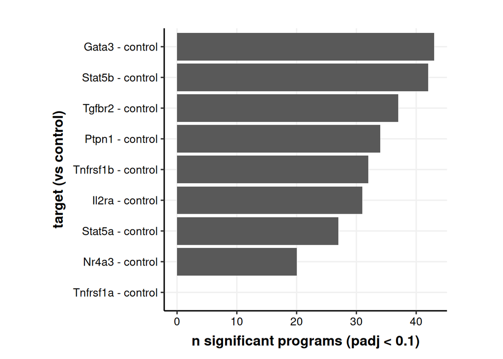

```r
target_assoc %>%
  group_by(contrast) %>%
  summarise(n_sig = sum(p_adj < sig_alpha), .groups = "drop") %>%
  ggplot(aes(x = reorder(contrast, n_sig), y = n_sig)) +
  geom_col() +
  coord_flip() +
  labs(x = "target (vs control)", y = paste0("n significant programs (padj < ", sig_alpha, ")")) +
  theme(aspect.ratio=1)
```

# Effect-size heatmap: TGFb/TNF class programs

- **left** — SIG30 KO effect: the emmeans `target` vs. `control` contrast from the section above, starred by its globally BH-adjusted p-value.
- **right** — the same programs in the original SIG18 ligand experiment, from SIG18’s `ligand1 * ligand2` model: the `TGFb` and `TNF` main effects, and their combined effect (`TGFb` + `TNF` + interaction, SIG18’s `estimate_total_interaction_model`). Left unstarred because no single coefficient tests that summed combined effect.

Note the two experiments push in opposite directions — SIG18 *adds* ligand while SIG30 *removes* a receptor — so for a ligand-driven program the two panels are expected to disagree in sign.

## Selecting programs

Rows are limited to the TGFb/TNF-relevant programs, split into three classes using SIG18’s own two-ligand model: the 5 most significant **positively synergistic** programs, the 5 most **TGFb-specific**, and the 5 most **TNF-specific**.

```r
# SIG18 tested several ligand1 arms (iTreg/TGFb/Th1/Th17/Th2) against ligand2 TNF;
# keep only the TGFb x TNF arm, where ligand1 == TGFb and ligand2 == TNF.
sig18_lm_scored <- read_csv(sig18_lm_scored_clean) %>%
  filter(interaction == "TGFb_TNF")

comp_class <- bind_rows(
  tibble(class     = "synergy positive",
         component = sig18_lm_scored %>%
           filter(interaction_class == "synergy positive") %>%
           slice_min(p_adj_interaction, n = 5) %>%
           pull(component)),
  tibble(class     = "tgfb",
         component = ligand_only_components(sig18_lm_scored, "p_adj_ligand1", "estimate_ligand1",
                                            "p_adj_ligand2", "estimate_ligand2")),
  tibble(class     = "tnf",
         component = ligand_only_components(sig18_lm_scored, "p_adj_ligand2", "estimate_ligand2",
                                            "p_adj_ligand1", "estimate_ligand1"))
) %>%
  distinct(component, .keep_all = TRUE) %>%
  arrange(class, component)

comp_class
```

```
## # A tibble: 15 × 2
##    class            component
##    <chr>            <chr>
##  1 synergy positive comp_18
##  2 synergy positive comp_3
##  3 synergy positive comp_38
##  4 synergy positive comp_39
##  5 synergy positive comp_7
##  6 tgfb             comp_15
##  7 tgfb             comp_19
##  8 tgfb             comp_29
##  9 tgfb             comp_35
## 10 tgfb             comp_8
## 11 tnf              comp_0
## 12 tnf              comp_14
## 13 tnf              comp_27
## 14 tnf              comp_48
## 15 tnf              comp_52
```

## Building the matrices

```r
# row annotation + row order, shared by both panels
ann_row  <- comp_class %>% column_to_rownames("component")
row_order <- rownames(ann_row)
gaps_row <- head(cumsum(table(ann_row$class)), -1)
class_colors <- setNames(
  brewer.pal(max(3, n_distinct(ann_row$class)), "Set2")[seq_len(n_distinct(ann_row$class))],
  sort(unique(ann_row$class))
)

# column order for each panel (KO targets grouped by pathway; ligand arms)
SIG30_order <- c("Stat5b", "Stat5a", "Il2ra", "Gata3", "Tgfbr2", "Ptpn1", "Nr4a3", "Tnfrsf1b", "Tnfrsf1a")
SIG18_order <- c("TNF", "TGFb", "TGFb+TNF")

# SIG30 KO: emmeans estimate of target vs control, and its matching p-value
mat_sgrna   <- as_program_matrix(target_assoc, "target", "estimate", row_order, SIG30_order)
stars_sgrna <- as_program_matrix(target_assoc, "target", "p_adj", row_order, SIG30_order) %>%
  stars_from_padj()

# SIG18 ligands: main effects of each ligand, plus their combined effect
# (estimate_ligand1 + estimate_ligand2 + estimate_interaction, precomputed by SIG18)
mat_sig18 <- sig18_lm_scored %>%
  dplyr::select(program = component,
                TNF        = estimate_ligand2,
                TGFb       = estimate_ligand1,
                `TGFb+TNF` = estimate_total_interaction_model) %>%
  pivot_longer(-program, names_to = "condition", values_to = "estimate") %>%
  as_program_matrix("condition", "estimate", row_order, SIG18_order)
```

## Drawing

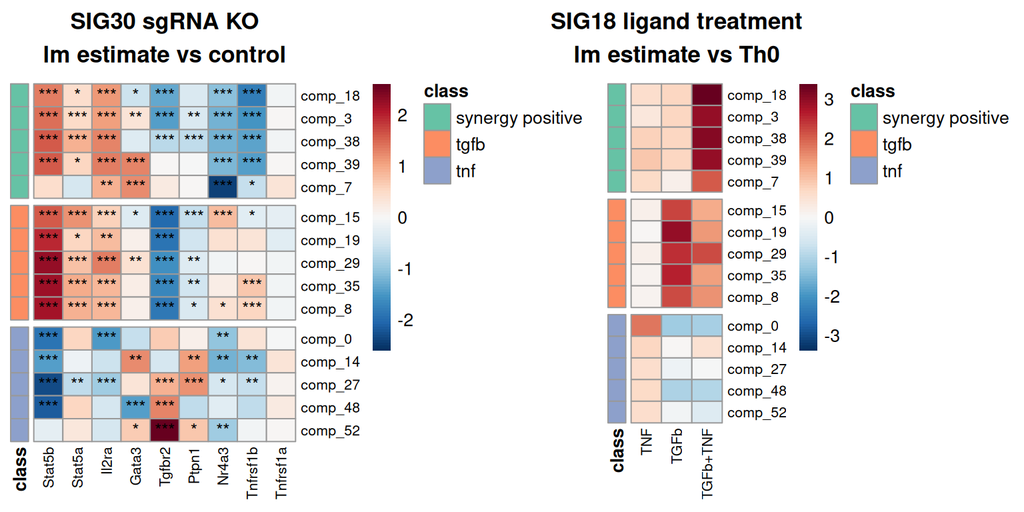

```r
hm_colors <- colorRampPalette(rev(brewer.pal(11, "RdBu")))(100)

# `mat`/`stars` already carry the intended row and column order (see above), so
# no reordering happens here. `stars = NULL` draws the panel without annotations.
plot_class_heatmap <- function(mat, title, stars = NULL) {
  hm_breaks <- seq(-max(abs(min(mat)),max(mat)), max(abs(min(mat)),max(mat)), length.out = 101)
  pheatmap(mat,
           color = hm_colors, breaks = hm_breaks,
           annotation_row = ann_row,
           annotation_colors = list(class = class_colors),
           cluster_rows = FALSE, cluster_cols = FALSE,
           gaps_row = gaps_row,
           main = title,
           display_numbers = if (is.null(stars)) FALSE else stars,
           fontsize_number = 10, number_color = "black",
           fontsize_row = 8, fontsize_col = 8, silent = TRUE,
           angle_col = 90)
}

combined_hm <- arrangeGrob(
  plot_class_heatmap(mat_sgrna, "SIG30 sgRNA KO\nlm estimate vs control", stars_sgrna)$gtable,
  plot_class_heatmap(mat_sig18, "SIG18 ligand treatment\nlm estimate vs Th0")$gtable,
  ncol = 2, widths = c(1.4, 1)
)

grid.newpage()
grid.draw(combined_hm)
```

```r
pdf(file.path(out_dir, paste0("scoreHeatmap_classEstimate_SIG18vsSIG30_", score_method, ".pdf")),
    width = 8, height = 4)
grid.draw(combined_hm)
dev.off()
```

The SIG30 panel on its own, transposed to targets x programs for a wide figure. The program class annotation and its gaps move from rows to columns with the transpose, so `ann_row`/`gaps_row` are passed as `annotation_col`/`gaps_col`.

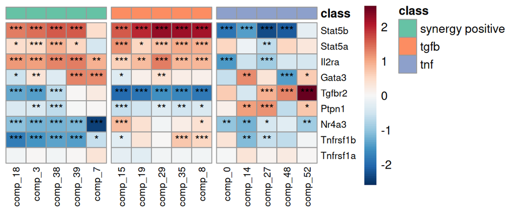

```r
hm_breaks <- seq(-max(abs(min(mat_sgrna)),max(mat_sgrna)),
                 max(abs(min(mat_sgrna)),max(mat_sgrna)), length.out = 101)
hm <- pheatmap(
  t(mat_sgrna),
  color = hm_colors,
  breaks = hm_breaks,
  annotation_col = ann_row,
  annotation_colors = list(class = class_colors),
  cluster_rows = FALSE,
  cluster_cols = FALSE,
  gaps_col = gaps_row,
  display_numbers = t(stars_sgrna),
  fontsize_number = 10,
  number_color = "black",
  fontsize_row = 8,
  fontsize_col = 8,
  angle_col = 90
)
```

```r
save_pheatmap_pdf(hm, file.path(out_dir, "scoreHeatmap_classEstimate_SIG30_waggr.pdf"), width = 6, height = 2.5)
```

# Volcano plots (target effect per program)

One panel per KO target: the program’s score effect vs. `control` against its significance, with programs at padj < 0.1 labelled.

Each point is additionally annotated with how that program behaved in SIG18: fill = the estimate of a chosen SIG18 model term, size = that term’s `-log10(padj)`, both from `lm_fit_zscore_degs_alpha10.0_sPCA.csv`. Three overlays are drawn — the TGFb x TNF interaction, and each ligand’s main effect.

```r
sig18_lm_fit <- read_csv(sig18_lm_fit_path)

volcano_interaction <- function(overlay_term) {
  overlay <- sig18_lm_fit %>%
    filter(term == overlay_term) %>%
    dplyr::select(program = component, estimate_overlay = estimate, p_adj_overlay = p_adj)

  target_assoc %>%
    left_join(overlay, by = "program") %>%
    ggplot(aes(x = estimate, y = -log10(p_adj))) +
    geom_hline(yintercept = -log10(sig_alpha), lty = 2, color = "grey60") +
    geom_vline(xintercept = 0, lty = 2, color = "grey60") +
    geom_point(aes(fill = estimate_overlay, size = -log10(p_adj_overlay)), shape = 21) +
    geom_text_repel(aes(label = ifelse(p_adj < sig_alpha, program, "")),
                    size = 2, max.overlaps = 15) +
    scale_fill_distiller(palette = "RdBu") +
    facet_wrap(~ contrast) +
    theme(aspect.ratio = 1) +
    labs(title = paste0("SIG18 programs — SIG30 (", score_method, ")"),
         x = "score effect vs control (SD)",
         fill = paste0("estimate\n", overlay_term),
         size = paste0("pscore\n", overlay_term))
}
```

```r
overlays <- c("ligand1TGFb:ligand2TNF", "ligand1TGFb", "ligand2TNF")

walk(overlays, \(ov) {
  p <- volcano_interaction(ov)
  print(p)
  ggsave(file.path(out_dir, paste0("scoreVolcano_SIG18_", gsub("[^A-Za-z0-9]+", "_", ov),
                                   "_", score_method, "_SIG30.pdf")),
         p, width = 14, height = 12)
})
```

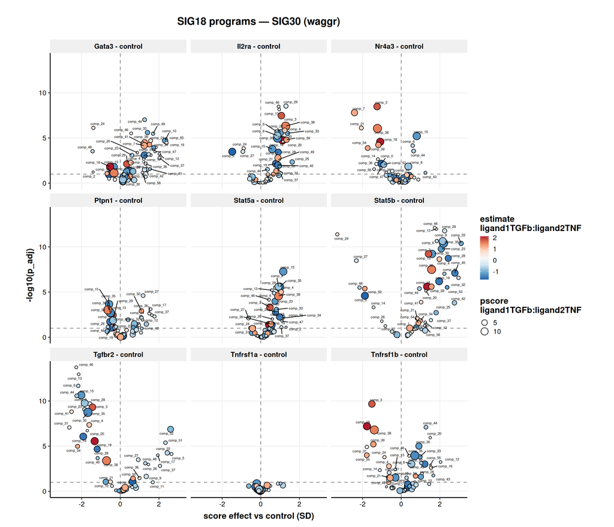

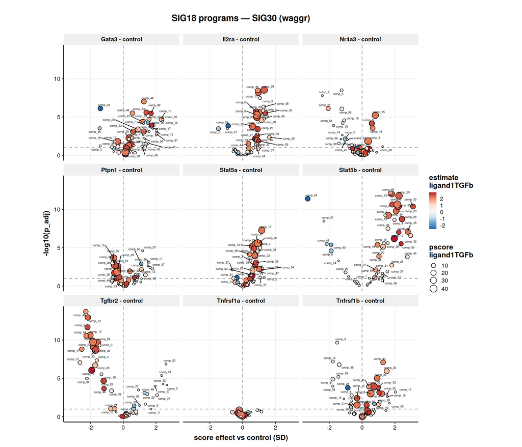

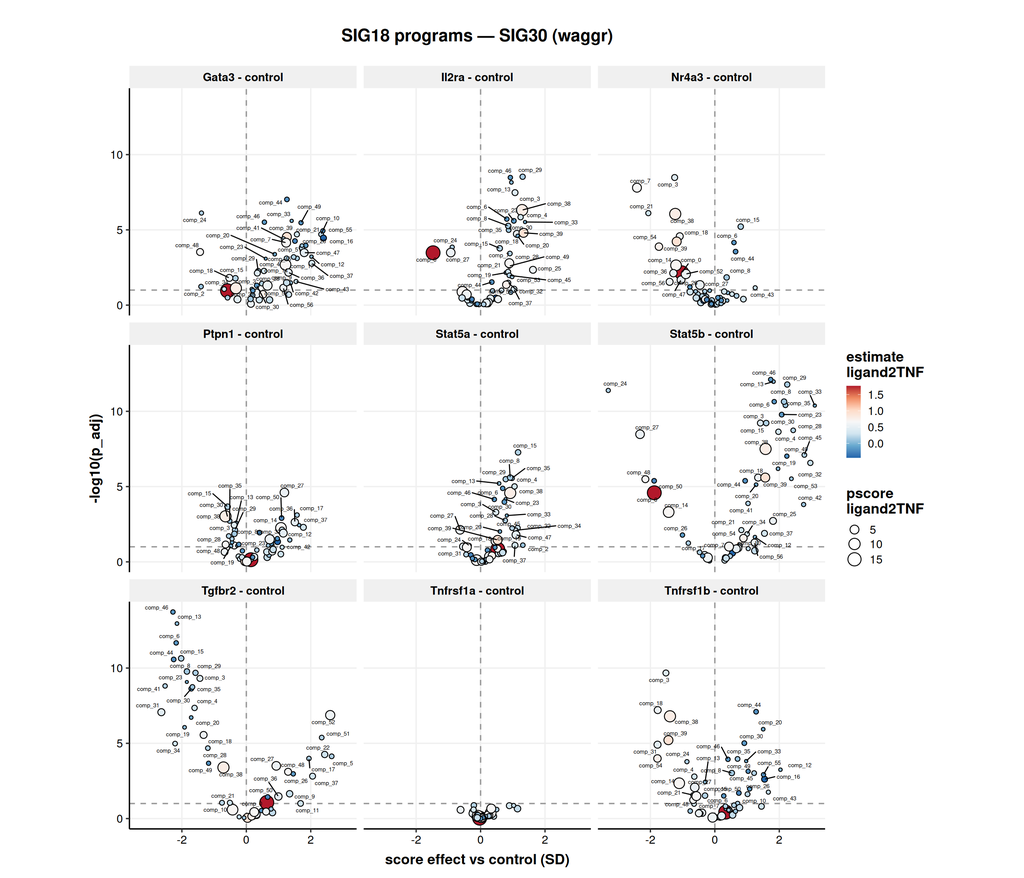